# Case-Study-1-LendingClub_Analysis

Kushal Regmi

7/8/2022

# Package Initialization

```r
library(tidyverse)
library(caret)
library(elasticnet)
library(readr)
```

```r
loans_full_schema <- read.csv("loans_full_schema.csv")
summary(loans_full_schema)
```

```
##    emp_title      emp_length        state       homeownership
##         : 833   Min.   : 0.00   CA     :1330   MORTGAGE:4789
##  manager: 218   1st Qu.: 2.00   TX     : 806   OWN     :1353
##  owner  : 204   Median : 6.00   NY     : 793   RENT    :3858
##  teacher: 201   Mean   : 5.93   FL     : 732
##  driver : 123   3rd Qu.:10.00   IL     : 382
##  sales  :  97   Max.   :10.00   NJ     : 338
##  (Other):8324   NA's   :817     (Other):5619
##  annual_income            verified_income debt_to_income   annual_income_joint
##  Min.   :      0   Not Verified   :3594   Min.   :  0.00   Min.   :  19200
##  1st Qu.:  45000   Source Verified:4116   1st Qu.: 11.06   1st Qu.:  86834
##  Median :  65000   Verified       :2290   Median : 17.57   Median : 113000
##  Mean   :  79222                          Mean   : 19.31   Mean   : 127915
##  3rd Qu.:  95000                          3rd Qu.: 25.00   3rd Qu.: 151546
##  Max.   :2300000                          Max.   :469.09   Max.   :1100000
##                                           NA's   :24       NA's   :8505
##    verification_income_joint debt_to_income_joint   delinq_2y
##                 :8545        Min.   : 0.32        Min.   : 0.000
##  Not Verified   : 611        1st Qu.:14.16        1st Qu.: 0.000
##  Source Verified: 499        Median :19.72        Median : 0.000
##  Verified       : 345        Mean   :19.98        Mean   : 0.216
##                              3rd Qu.:25.50        3rd Qu.: 0.000
##                              Max.   :39.98        Max.   :13.000
##                              NA's   :8505
##  months_since_last_delinq earliest_credit_line inquiries_last_12m
##  Min.   :  1.00           Min.   :1963         Min.   : 0.000
##  1st Qu.: 19.00           1st Qu.:1997         1st Qu.: 0.000
##  Median : 34.00           Median :2003         Median : 1.000
##  Mean   : 36.76           Mean   :2001         Mean   : 1.958
##  3rd Qu.: 53.00           3rd Qu.:2006         3rd Qu.: 3.000
##  Max.   :118.00           Max.   :2015         Max.   :29.000
##  NA's   :5658
##  total_credit_lines open_credit_lines total_credit_limit total_credit_utilized
##  Min.   : 2.00      Min.   : 0.0      Min.   :      0    Min.   :     0
##  1st Qu.:14.00      1st Qu.: 7.0      1st Qu.:  51594    1st Qu.: 19186
##  Median :21.00      Median :10.0      Median : 114667    Median : 36927
##  Mean   :22.68      Mean   :11.4      Mean   : 183606    Mean   : 51049
##  3rd Qu.:29.00      3rd Qu.:14.0      3rd Qu.: 267550    3rd Qu.: 65421
##  Max.   :87.00      Max.   :51.0      Max.   :3386034    Max.   :942456
##
```

[output cut: 89 more lines]

```
##  Min.   :    0   Min.   :    0.0   Min.   :    0.0   Min.   :   0.0
##  1st Qu.: 6679   1st Qu.:  928.7   1st Qu.:  587.1   1st Qu.: 221.8
##  Median :12380   Median : 1563.3   Median :  985.0   Median : 446.1
##  Mean   :14459   Mean   : 2494.2   Mean   : 1894.5   Mean   : 599.7
##  3rd Qu.:20690   3rd Qu.: 2616.0   3rd Qu.: 1694.6   3rd Qu.: 825.4
##  Max.   :40000   Max.   :41630.4   Max.   :40000.0   Max.   :4216.4
##
##  paid_late_fees
##  Min.   : 0.0000
##  1st Qu.: 0.0000
##  Median : 0.0000
##  Mean   : 0.1195
##  3rd Qu.: 0.0000
##  Max.   :52.9800
##
```

# Exploratory Data Analysis Insights

### The dataset for this particular analysis involves thousands of loans made through the Lending Club platform, which is an online platform that specializes in fulfilling personal loan to individuals. The dataset in particular provides information regarding different loan recipients with 55 fields ranging from employment title to distribution methods. In looking at the data, the length of variables at play are vast and both qualitative and quantitative. Fields such as annual_joint_income and months_since_last_delinq contain large number of NA values for many recipients which is important to consider when moving forward in the analysis.

# Data Visualization

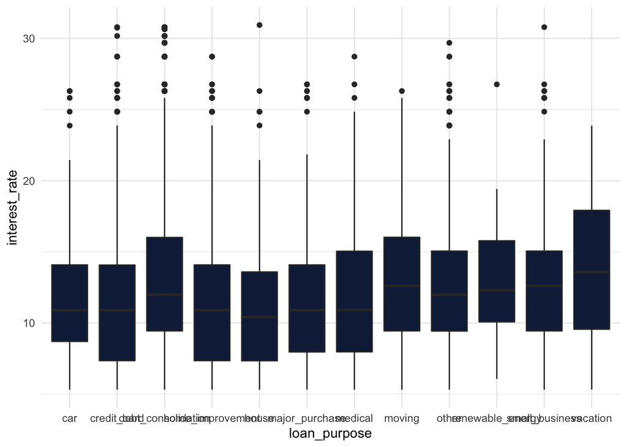

```r
ggplot(loans_full_schema) +
  aes(x = loan_purpose, y = interest_rate) +
  geom_boxplot(fill = "#112446") +
  theme_minimal()
```

### Examining the plot above we see that those who took out loans for debt_consolidation, moving, and vacation observed the highest interest rates, with vacation purposes having the highest mean interest rates. In addition the most outliers with high interest rates were apparent in those who took out loans for credit cards, debt consolidation, and others.

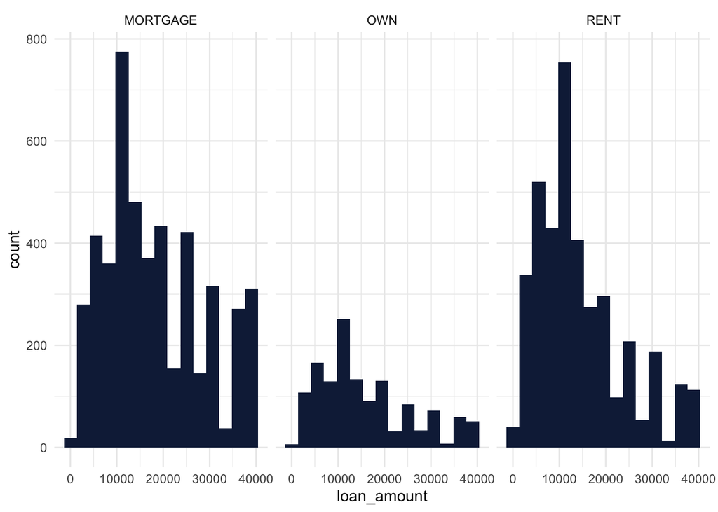

```r
ggplot(loans_full_schema) +
  aes(x = loan_amount) +
  geom_histogram(bins = 15L, fill = "#112446") +
  theme_minimal() +
  facet_wrap(vars(homeownership))
```

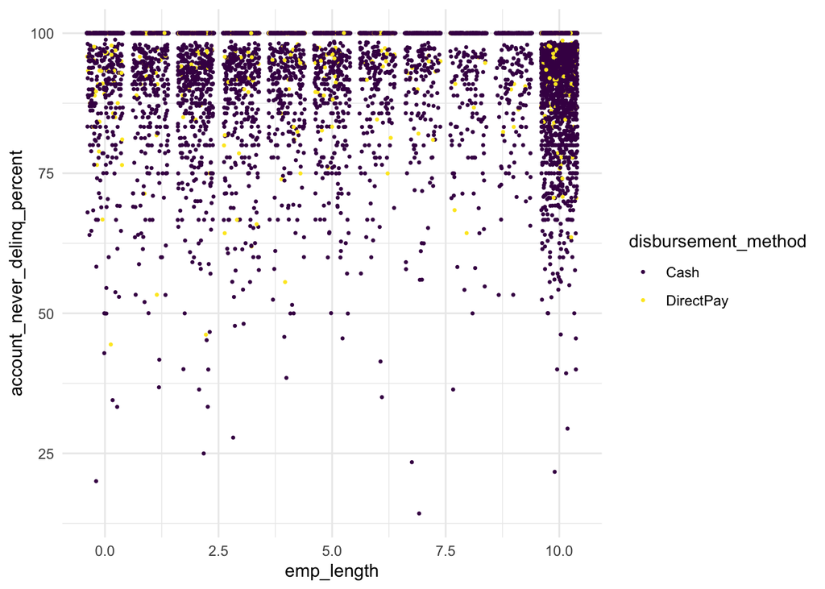

```r
ggplot(loans_full_schema) +
  aes(
    x = emp_length,
    y = account_never_delinq_percent,
    colour = disbursement_method
  ) +
  geom_jitter(size = 0.5) +
  scale_color_manual(
    values = c(Cash = "#440154",
    DirectPay = "#FDE725")
  ) +
  theme_minimal()
```

### The jitter plot above shows the percentage of each recipiant account that have never gone delinquent as it relates to their employment length history. The type of disbursement method is differentiated by color as either cash or direct pay. Observing this graphic we notice an overwelming amount of individuals opted to receive their loans in cash form. In addition, there is a noticable cluster of individuals with employment length around 10 years having accounts never delinquent 75-100 percent throughout their history.

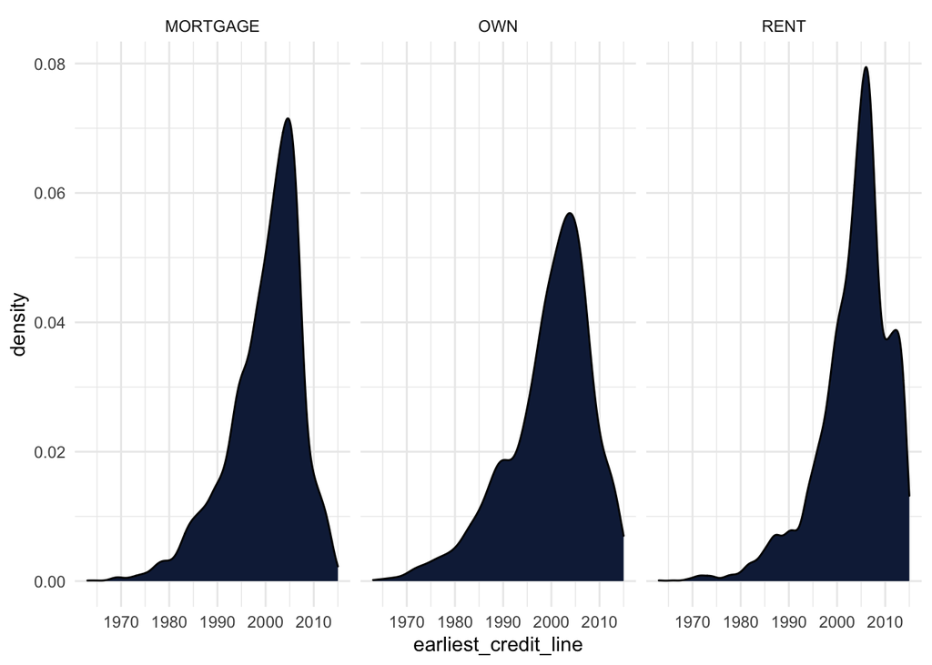

```r
ggplot(loans_full_schema) +
  aes(x = earliest_credit_line) +
  geom_density(adjust = 1L, fill = "#112446") +
  theme_minimal() +
  facet_wrap(vars(homeownership))
```

### The density plot above shows the earliest credit line obtained by individuals observed by their homeowner status. Individuals who rent have the highest density with recent credit history while individuals who already own a home have the highest density with older credit history.

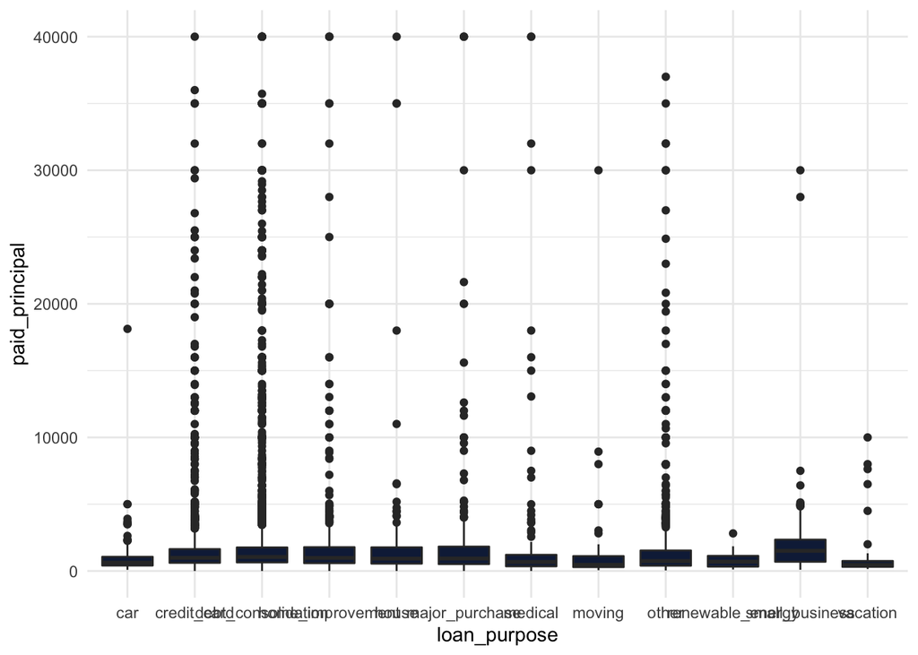

```r
ggplot(loans_full_schema) +
  aes(x = loan_purpose, y = paid_principal) +
  geom_boxplot(fill = "#112446") +
  theme_minimal()
```

### The boxplot above shows the amount of paid princial for loans of individuals as it relates to their loan purposes. Those who took out car and vacaion loans appear to have the paid the least priciple amount, however, this could be as a result of the loan sizes that many take out for these purposes. Credit card, debt consolidation, and other loans show the highest number of outliers who paid principle balances higher than the mean of their category. Those who took out moving, renewable energy, small business, and car loans show to have the least outliers of paid principle outside their repected mean amounts per category.

# Data Cleansing for Interest Rate Prediction Regression Models

### For the models that will be created for interest rate prediction we will only focus on the quantitative variables involved in the dataset. We create a subset of the full schema dataset which will only pertain to quantifiable metrics that will be used for our models.

# Muti-Modal Regression

```r
nums <- unlist(lapply(loans_full_schema, is.numeric))

loan_numeric <- loans_full_schema[ , nums]

loan_purpose <- lm(formula = interest_rate ~. , data = loan_numeric)

summary(loan_purpose)
```

```
##
## Call:
## lm(formula = interest_rate ~ ., data = loan_numeric)
##
## Residuals:
##     Min      1Q  Median      3Q     Max
## -5.7853 -1.8357 -0.2519  1.4814  9.1056
##
## Coefficients: (5 not defined because of singularities)
##                                    Estimate Std. Error t value Pr(>|t|)
## (Intercept)                      -9.217e+01  6.494e+01  -1.419  0.15766
## emp_length                        6.853e-02  6.183e-02   1.108  0.26932
## annual_income                    -1.141e-05  8.479e-06  -1.345  0.18032
## debt_to_income                   -6.436e-03  9.719e-03  -0.662  0.50878
## annual_income_joint               1.288e-05  6.080e-06   2.118  0.03567 *
## debt_to_income_joint              3.867e-02  3.595e-02   1.076  0.28359
## delinq_2y                        -1.545e-01  2.515e-01  -0.614  0.53988
## months_since_last_delinq         -2.982e-02  1.489e-02  -2.003  0.04684 *
## earliest_credit_line              4.628e-02  3.239e-02   1.429  0.15502
## inquiries_last_12m                6.226e-02  1.027e-01   0.606  0.54513
## total_credit_lines                2.402e-02  4.165e-02   0.577  0.56486
## open_credit_lines                -6.357e-01  2.262e+00  -0.281  0.77899
## total_credit_limit               -1.593e-06  1.465e-06  -1.087  0.27841
## total_credit_utilized            -4.462e-06  5.860e-06  -0.761  0.44748
## num_collections_last_12m          3.176e+00  1.790e+00   1.775  0.07781 .
## num_historical_failed_to_pay     -5.095e-01  7.364e-01  -0.692  0.49003
## months_since_90d_late             1.854e-02  1.320e-02   1.404  0.16205
## current_accounts_delinq                  NA         NA      NA       NA
## total_collection_amount_ever     -3.318e-05  2.000e-04  -0.166  0.86843
## current_installment_accounts     -1.069e-01  4.282e-01  -0.250  0.80321
## accounts_opened_24m               5.531e-02  8.789e-02   0.629  0.53001
## months_since_last_credit_inquiry -1.109e-01  4.419e-02  -2.510  0.01302 *
## num_satisfactory_accounts         7.013e-01  2.239e+00   0.313  0.75448
## num_accounts_120d_past_due               NA         NA      NA       NA
## num_accounts_30d_past_due                NA         NA      NA       NA
## num_active_debit_accounts         4.789e-01  2.002e-01   2.392  0.01786 *
## total_debit_limit                -4.913e-05  1.657e-05  -2.966  0.00346 **
## num_total_cc_accounts            -2.585e-02  6.203e-02  -0.417  0.67736
## num_open_cc_accounts             -1.079e-01  4.386e-01  -0.246  0.80604
## num_cc_carrying_balance          -1.034e-01  1.751e-01  -0.590  0.55577
## num_mort_accounts                -3.821e-01  1.779e-01  -2.148  0.03320 *
## account_never_delinq_percent      5.539e-03  2.025e-02   0.274  0.78476
## tax_liens                        -1.446e+00  1.355e+00  -1.067  0.28744
## public_record_bankrupt                   NA         NA      NA       NA
## loan_amount                      -5.578e+02  5.654e+02  -0.987  0.32529
## term                              3.323e-01  3.991e-02   8.327 2.95e-14 ***
## installment                       3.062e-02  3.526e-03   8.686 3.42e-15 ***
## balance                           5.578e+02  5.654e+02   0.987  0.32529
## paid_total                        5.578e+02  5.654e+02   0.987  0.32529
## paid_principal                           NA         NA      NA       NA
## paid_interest                    -5.578e+02  5.654e+02  -0.987  0.32530
## paid_late_fees                   -5.578e+02  5.654e+02  -0.987  0.32530
## ---
## Signif. codes:  0 '***' 0.001 '**' 0.01 '*' 0.05 '.' 0.1 ' ' 1
##
## Residual standard error: 2.874 on 166 degrees of freedom
##   (9797 observations deleted due to missingness)
## Multiple R-squared:  0.7769, Adjusted R-squared:  0.7285
## F-statistic: 16.06 on 36 and 166 DF,  p-value: < 2.2e-16
```

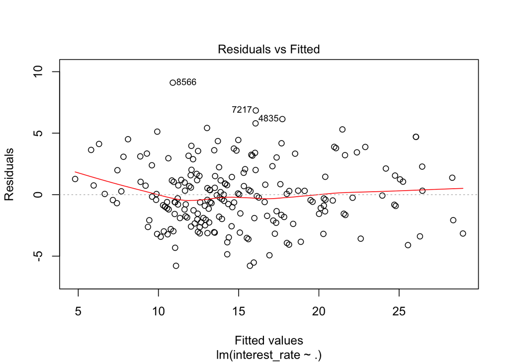

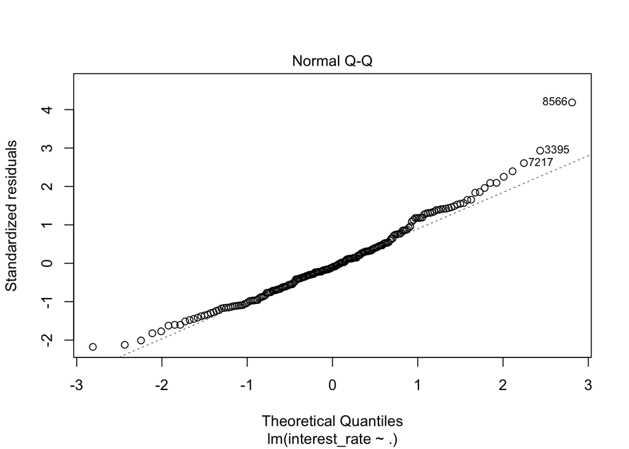

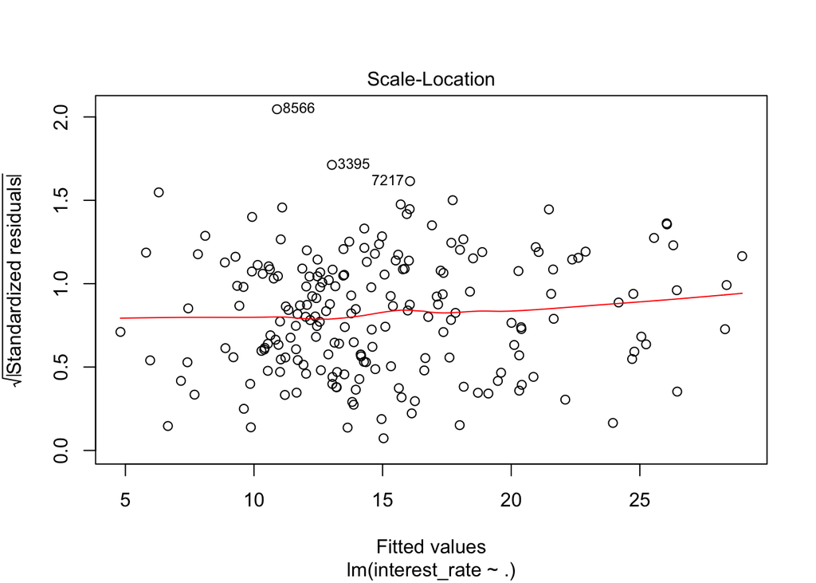

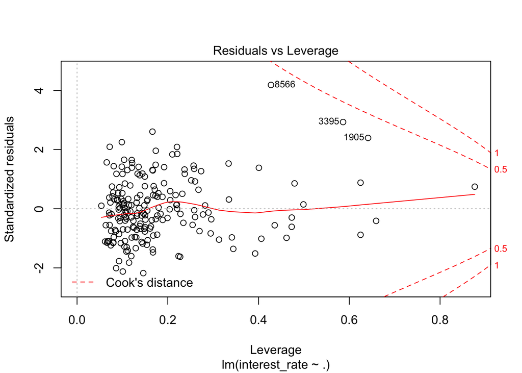

```r
plot(loan_purpose)
```

### Observing the regression model and its summary we see numerous statistics that give meaninful confidence to its performance in predicting interest rate. Our adjusted R-squared value stands at 0.7285 which gives fair validity as to accuracy. We also notices variables of high statisitical significance such as total_debit_limit, term, and installment which had the lowest p-values in our model. The Q-Q plot also shows positive linearity with few outliers.

## Feature set with 8 fields for consideration

```r
# feature set

loan_feature <- loans_full_schema %>%
  select(emp_length, annual_income, debt_to_income, total_credit_lines, total_credit_limit, total_credit_utilized, num_historical_failed_to_pay, interest_rate, num_satisfactory_accounts) %>%
  na.omit(loan_feature)
```

## Correlation comparison of variables in feature set

```r
cor(loan_feature)
```

```
##                               emp_length annual_income debt_to_income
## emp_length                    1.00000000    0.09637301    0.026156942
## annual_income                 0.09637301    1.00000000   -0.176662463
## debt_to_income                0.02615694   -0.17666246    1.000000000
## total_credit_lines            0.13353863    0.20425479    0.215237765
## total_credit_limit            0.14767433    0.51252855    0.081412336
## total_credit_utilized         0.01969838    0.39301691    0.255106322
## num_historical_failed_to_pay  0.02997835    0.03064645   -0.008046001
## interest_rate                -0.02973393   -0.09696025    0.148666341
## num_satisfactory_accounts     0.06713565    0.16796862    0.230842638
##                              total_credit_lines total_credit_limit
## emp_length                          0.133538634         0.14767433
## annual_income                       0.204254786         0.51252855
## debt_to_income                      0.215237765         0.08141234
## total_credit_lines                  1.000000000         0.38881316
## total_credit_limit                  0.388813158         1.00000000
## total_credit_utilized               0.464608629         0.51648385
## num_historical_failed_to_pay       -0.007491011        -0.02694062
## interest_rate                      -0.035561959        -0.12869558
## num_satisfactory_accounts           0.753817168         0.32489660
##                              total_credit_utilized num_historical_failed_to_pay
## emp_length                              0.01969838                  0.029978347
## annual_income                           0.39301691                  0.030646446
## debt_to_income                          0.25510632                 -0.008046001
## total_credit_lines                      0.46460863                 -0.007491011
## total_credit_limit                      0.51648385                 -0.026940617
## total_credit_utilized                   1.00000000                 -0.017400981
## num_historical_failed_to_pay           -0.01740098                  1.000000000
## interest_rate                           0.03493574                  0.039045144
## num_satisfactory_accounts               0.40657360                  0.018268702
##                              interest_rate num_satisfactory_accounts
## emp_length                    -0.029733927               0.067135647
## annual_income                 -0.096960247               0.167968618
## debt_to_income                 0.148666341               0.230842638
## total_credit_lines            -0.035561959               0.753817168
## total_credit_limit            -0.128695577               0.324896603
## total_credit_utilized          0.034935742               0.406573604
## num_historical_failed_to_pay   0.039045144               0.018268702
## interest_rate                  1.000000000              -0.009207363
## num_satisfactory_accounts     -0.009207363               1.000000000
```

# Ridge Regression Model with 10 fold Cross Validation for interest rate prediction on selected features.

```r
fitControl <- trainControl(## 10-fold CV
                           method = "repeatedcv",
                           number = 10,
                           repeats = 10,
                           search = "random")

model_ridge <- train(interest_rate ~ .,
               data = loan_feature,
               method = "ridge",
               trControl = fitControl,
               preProcess = c('scale', 'center'),
               na.action = na.omit)
```

```r
# prediction of interest rate from ridge regression model
predictions <- predict(model_ridge, loan_feature)

predictions %>%
  head(20)
```

```
##        1        2        3        4        5        7        8        9
## 12.52987 12.04651 12.65610 12.90174 14.92774 12.08633 11.42542 12.79725
##       10       11       12       13       14       16       18       19
## 13.05262 12.55486 10.29402 11.29520  9.90545 13.85098 13.26028 11.35790
##       20       21       22       23
## 10.80650 12.60618 12.98879 11.11736
```

```r
model_ridge
```

```
## Ridge Regression
##
## 9182 samples
##    8 predictor
##
## Pre-processing: scaled (8), centered (8)
## Resampling: Cross-Validated (10 fold, repeated 10 times)
## Summary of sample sizes: 8265, 8264, 8265, 8264, 8264, 8261, ...
## Resampling results across tuning parameters:
##
##   lambda        RMSE      Rsquared    MAE
##   7.055349e-05  4.883052  0.05176022  3.828534
##   8.500290e-05  4.883052  0.05176025  3.828534
##   3.584410e-02  4.883130  0.05179046  3.828664
##
## RMSE was used to select the optimal model using the smallest value.
## The final value used for the model was lambda = 8.50029e-05.
```

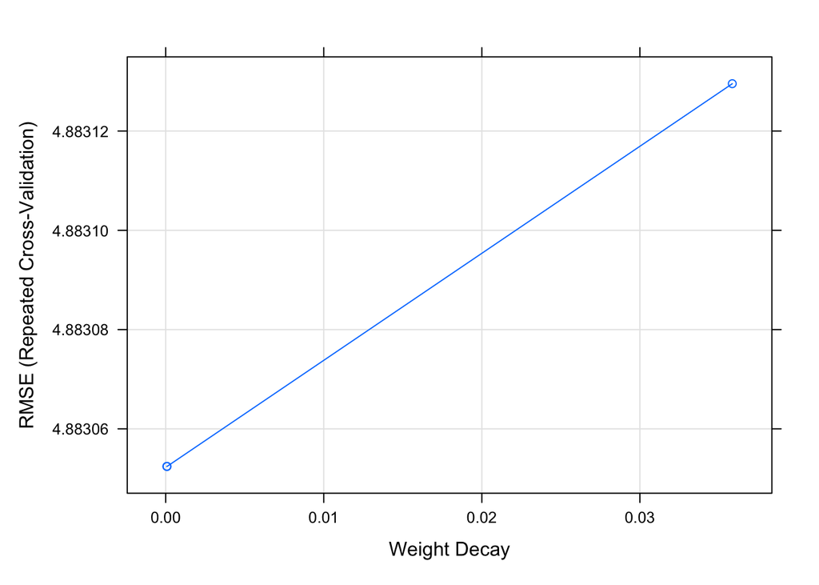

```r
plot(model_ridge)
```

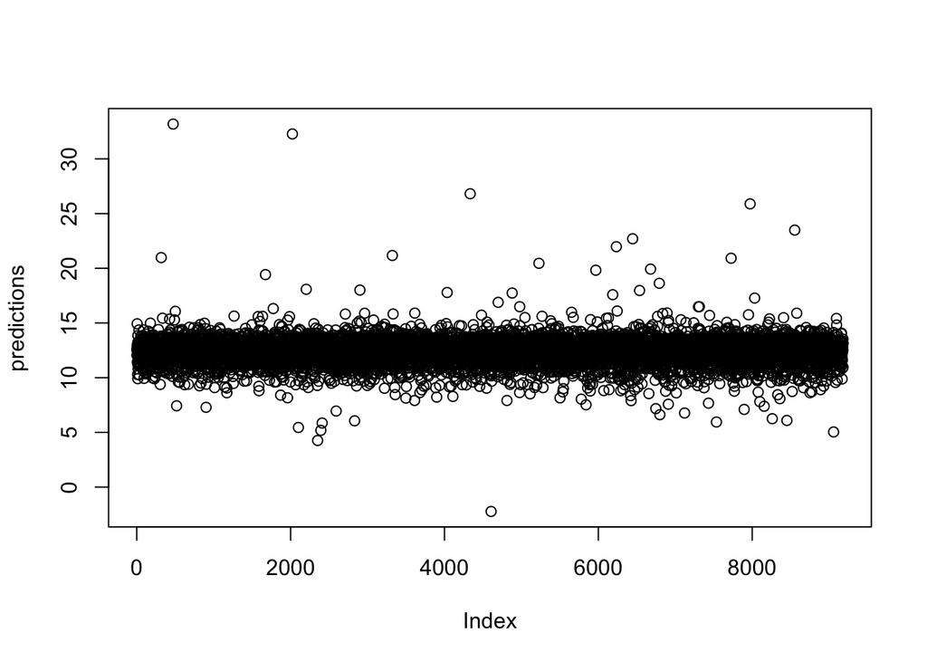

```r
plot(predictions)
```

### The linear plot above shows the Root Mean Squared Error of the model as it relates to the weight decay value signified as lambda. The summary of our model shows the lowest Root Mean Squared Error observed at the lambda weight decay value which is signified in the plot as well. The secondary scatter plot shows the predicted interest rates for indivisuals. Most of the individuals in the index range have predicted interests rate ranging from 10-15%.

# Further Improvements

## For further improvements I would work on finding the best fit hyperparameters for the ridge regression model using different parameters available in the train function. Experimenting with other regression methods such as lasso and even clustering algorithms would allow for better comparison of model performances and the ability to determine those of best fit.